# HW Week 11

## Week 11

### Step 1: Load required libraries

```r
library("data.table")
library("lme4")
library("dplyr")
library("ggplot2")
library("lattice")
```

### Step 2: Load data

```r
NLSY_wide <- fread("NLSY.txt", na.strings = ".")
NLSY_wide
```

| id | read1 | read2 | read3 | read4 | boy | m_age | age | cognition | emotion | SMS |
| --- | --- | --- | --- | --- | --- | --- | --- | --- | --- | --- |
| 22 | 21 | 39 | NA | NA | 0 | 28 | 6.08 | 12 | 10 | 0 |
| 34 | 21 | 29 | 45 | 45 | 1 | 28 | 6.83 | 8 | 9 | 0 |
| 58 | 23 | 45 | 42 | 46 | 0 | 28 | 6.50 | 8 | 6 | 0 |
| 122 | 37 | 80 | NA | NA | 1 | 28 | 7.83 | 12 | 10 | 0 |
| 125 | 23 | 38 | 43 | 62 | 0 | 29 | 7.42 | 9 | 8 | 0 |
| 133 | 18 | 26 | 41 | 40 | 1 | 28 | 6.75 | 7 | 9 | 1 |
| 163 | 35 | 48 | 58 | 75 | 1 | 28 | 7.17 | 9 | 10 | 1 |
| 190 | 29 | 61 | NA | NA | 0 | 28 | 6.67 | 8 | 8 | 0 |
| 227 | 18 | 38 | 40 | NA | 0 | 29 | 6.25 | 11 | 10 | 0 |
| 248 | 35 | 57 | 70 | 69 | 0 | 28 | 7.50 | 8 | 9 | 1 |

[output cut: 395 more lines]

### Step 3: Create New Column Variables

Create 8 new column variables and remove the original two **m_age** and **age**

```r
NLSY_wide <- NLSY_wide %>%
  mutate(m_age1 = m_age,
         m_age2 = m_age + 2,
         m_age3 = m_age + 4,
         m_age4 = m_age + 6,
         c_age1 = age,
         c_age2 = age + 2,
         c_age3 = age + 4,
         c_age4 = age + 6) %>%
  select(-c(m_age, age))
NLSY_wide
```

| id | read1 | read2 | read3 | read4 | boy | cognition | emotion | SMS | m_age1 | m_age2 | m_age3 | m_age4 | c_age1 | c_age2 | c_age3 | c_age4 |
| --- | --- | --- | --- | --- | --- | --- | --- | --- | --- | --- | --- | --- | --- | --- | --- | --- |
| 22 | 21 | 39 | NA | NA | 0 | 12 | 10 | 0 | 28 | 30 | 32 | 34 | 6.08 | 8.08 | 10.08 | 12.08 |
| 34 | 21 | 29 | 45 | 45 | 1 | 8 | 9 | 0 | 28 | 30 | 32 | 34 | 6.83 | 8.83 | 10.83 | 12.83 |
| 58 | 23 | 45 | 42 | 46 | 0 | 8 | 6 | 0 | 28 | 30 | 32 | 34 | 6.50 | 8.50 | 10.50 | 12.50 |
| 122 | 37 | 80 | NA | NA | 1 | 12 | 10 | 0 | 28 | 30 | 32 | 34 | 7.83 | 9.83 | 11.83 | 13.83 |
| 125 | 23 | 38 | 43 | 62 | 0 | 9 | 8 | 0 | 29 | 31 | 33 | 35 | 7.42 | 9.42 | 11.42 | 13.42 |
| 133 | 18 | 26 | 41 | 40 | 1 | 7 | 9 | 1 | 28 | 30 | 32 | 34 | 6.75 | 8.75 | 10.75 | 12.75 |
| 163 | 35 | 48 | 58 | 75 | 1 | 9 | 10 | 1 | 28 | 30 | 32 | 34 | 7.17 | 9.17 | 11.17 | 13.17 |
| 190 | 29 | 61 | NA | NA | 0 | 8 | 8 | 0 | 28 | 30 | 32 | 34 | 6.67 | 8.67 | 10.67 | 12.67 |
| 227 | 18 | 38 | 40 | NA | 0 | 11 | 10 | 0 | 29 | 31 | 33 | 35 | 6.25 | 8.25 | 10.25 | 12.25 |
| 248 | 35 | 57 | 70 | 69 | 0 | 8 | 9 | 1 | 28 | 30 | 32 | 34 | 7.50 | 9.50 | 11.50 | 13.50 |

[output cut: 395 more lines]

### Step 3: Trasform data format

We now transform the wide format into long format.The folowing function gathers Columns 2 to 5 into rows. In place of the four variable read1-read4, we get a **read_score** variable, the key is *id* and the corresponding value is **read_score**. Similiarly, Columns 10 to 13 collapse into **mother_age** and Columns 14 to 17 collapse into **child_age**. After reshaping the dataset, we remove rows containing missing values.

```r
NLSY_long <- NLSY_wide %>%
  reshape(direction = "long",
          idvar = c("id"),
          varying = list(c(2:5), c(10:13), c(14:17)),
          v.names = c("read_score", "mother_age", "child_age"),
          times = c("1", "2", "3", "4")) %>%
  na.omit()
NLSY_long
```

|  | id | boy | cognition | emotion | SMS | time | read_score | mother_age | child_age |
| --- | --- | --- | --- | --- | --- | --- | --- | --- | --- |
| 22.1 | 22 | 0 | 12 | 10 | 0 | 1 | 21 | 28 | 6.08 |
| 34.1 | 34 | 1 | 8 | 9 | 0 | 1 | 21 | 28 | 6.83 |
| 58.1 | 58 | 0 | 8 | 6 | 0 | 1 | 23 | 28 | 6.50 |
| 122.1 | 122 | 1 | 12 | 10 | 0 | 1 | 37 | 28 | 7.83 |
| 125.1 | 125 | 0 | 9 | 8 | 0 | 1 | 23 | 29 | 7.42 |
| 133.1 | 133 | 1 | 7 | 9 | 1 | 1 | 18 | 28 | 6.75 |
| 163.1 | 163 | 1 | 9 | 10 | 1 | 1 | 35 | 28 | 7.17 |
| 190.1 | 190 | 0 | 8 | 8 | 0 | 1 | 29 | 28 | 6.67 |
| 227.1 | 227 | 0 | 11 | 10 | 0 | 1 | 18 | 29 | 6.25 |
| 248.1 | 248 | 0 | 8 | 9 | 1 | 1 | 35 | 28 | 7.50 |

[output cut: 990 more lines]

Shift ages and change variable types

```r
NLSY_long <- within(NLSY_long, {
  id <- factor(id)
  boy <- factor(boy)
  time <- factor(time)
  mother_age <- mother_age - 6
  child_age <- child_age - 6
})
```

### Step 4: Plot data

We now plot the data for the first 50 children

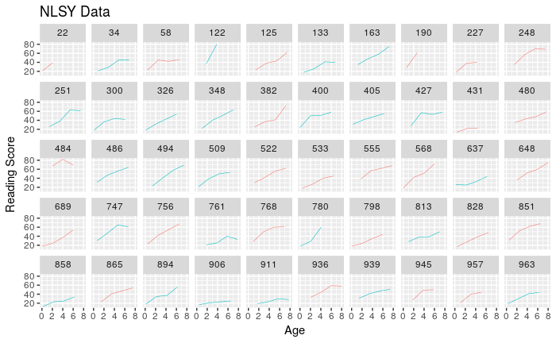

```r
temp_df <- NLSY_long %>% filter(id %in% NLSY_long$id[1:50])
ggplot(data = temp_df ,
       aes(x = child_age ,
           y = read_score,
           group = boy)) +
  facet_wrap( ~ id, ncol = 10) +
  geom_line(aes(colour = boy), size = 0.2) +
  xlab("Age") +
  ylab("Reading Score") +
  ggtitle("NLSY Data") +
  theme(legend.position = "none")
```

### Step 5: Fit Model

Here we fit a mixed effect model with random slopes but fixed intercept. You can change to 1 to have a random effect on the intercept.

```r
NLSY_fit1 <- lmer( read_score ~ child_age + I(child_age^2) + (0 + child_age + I(child_age^2)|id),
                  data = NLSY_long,
                  REML = FALSE)
summary(NLSY_fit1)
```

```
Linear mixed model fit by maximum likelihood  ['lmerMod']
Formula: read_score ~ child_age + I(child_age^2) + (0 + child_age + I(child_age^2) |      id)
   Data: NLSY_long

     AIC      BIC   logLik deviance df.resid
  9107.2   9143.5  -4546.6   9093.2     1318

Scaled residuals:
    Min      1Q  Median      3Q     Max
-3.3965 -0.4963 -0.0686  0.4001  6.6626

Random effects:
 Groups   Name           Variance Std.Dev. Corr
 id       child_age      19.0186  4.3610
          I(child_age^2)  0.1869  0.4323   -0.97
 Residual                26.1552  5.1142
Number of obs: 1325, groups:  id, 405

Fixed effects:
               Estimate Std. Error t value
(Intercept)    17.39664    0.37672   46.18
child_age       9.30596    0.32721   28.44
I(child_age^2) -0.49653    0.03841  -12.93

Correlation of Fixed Effects:
            (Intr) chld_g
child_age   -0.631
I(chld_g^2)  0.587 -0.952
```

Here we fit another model with the uncorrelated slopes. Note the double-bar notation.

```r
NLSY_fit2 <- lmer( read_score ~ child_age + I(child_age^2) + (1 + child_age ||id),
                  data = NLSY_long,
                  REML = FALSE)
summary(NLSY_fit2)
```

```
Linear mixed model fit by maximum likelihood  ['lmerMod']
Formula: read_score ~ child_age + I(child_age^2) + ((1 | id) + (0 + child_age |      id))
   Data: NLSY_long

     AIC      BIC   logLik deviance df.resid
  9161.0   9192.2  -4574.5   9149.0     1319

Scaled residuals:
    Min      1Q  Median      3Q     Max
-3.0091 -0.4743 -0.0341  0.4294  4.7116

Random effects:
 Groups   Name        Variance Std.Dev.
 id       (Intercept) 34.516   5.875
 id.1     child_age    2.553   1.598
 Residual             25.374   5.037
Number of obs: 1325, groups:  id, 405

Fixed effects:
               Estimate Std. Error t value
(Intercept)    17.40486    0.49105   35.44
child_age       9.27026    0.26356   35.17
I(child_age^2) -0.48928    0.03266  -14.98

Correlation of Fixed Effects:
            (Intr) chld_g
child_age   -0.661
I(chld_g^2)  0.587 -0.909
```

We can compare the two models using the anova function.

```r
anova(NLSY_fit2, NLSY_fit1)
```

```
Data: NLSY_long
Models:
NLSY_fit2: read_score ~ child_age + I(child_age^2) + ((1 | id) + (0 + child_age |
NLSY_fit2:     id))
NLSY_fit1: read_score ~ child_age + I(child_age^2) + (0 + child_age + I(child_age^2) |
NLSY_fit1:     id)
          Df    AIC    BIC  logLik deviance  Chisq Chi Df Pr(>Chisq)
NLSY_fit2  6 9161.0 9192.2 -4574.5   9149.0
NLSY_fit1  7 9107.2 9143.5 -4546.6   9093.2 55.861      1  7.779e-14 ***
---
Signif. codes:  0 ‘***’ 0.001 ‘**’ 0.01 ‘*’ 0.05 ‘.’ 0.1 ‘ ’ 1
```

Note that the REML depends the fixed effects in the model. We should not compare models fit using REML if you change the fixed effects in your model. If the focus of your analysis is estimating the random effects, then REML is generally considered to give better estimates. Either way, it is better to fit your best model using REML for final inference. If you your two models have the same random effects structure, then to compare models with **Nested** fixed effects, use ML estimation and not REML.

To extract the variances, simply run the following:

```r
(vc <- VarCorr(NLSY_fit1))
```

```
 Groups   Name           Std.Dev. Corr
 id       child_age      4.36103
          I(child_age^2) 0.43227  -0.967
 Residual                5.11422
```

```r
print(vc, comp = c("Variance"))
```

```
 Groups   Name           Variance Corr
 id       child_age      19.01857
          I(child_age^2)  0.18686 -0.967
 Residual                26.15523
```

To get the covariance, use the following fomula: **Cov(i,j) = Corr(i,j)*Sigma(i)*Sigma(j)**

### Step 6: Check Model

Plot residuals vs fitted.

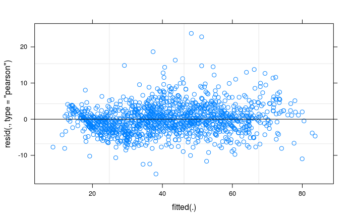

```r
plot(NLSY_fit2)
```

Plot the random effects. They should have a normal distribution.

```r
ranef_betas <- ranef(NLSY_fit2, condVar = TRUE)
```

```
conditional variances not currently available via ranef when there are multiple terms per factor
```

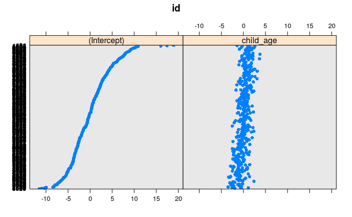

```r
dotplot(ranef_betas)
```

To check normality assumption, we use the quantile-quantile plot of a sample against a theoretical distribution.

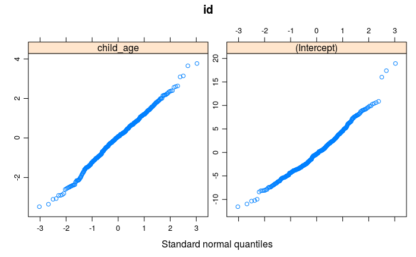

```r
qqmath(ranef_betas)
```

### Extra Step 7: Computing Confidence intervals

Computing confidence intervals can be done via Wald approximations (for fixed-effects parameters only), likelihood profiling, or parametric bootstrapping. The boostrap confidence intervals can be computed using the following types, “norm”, “basic”, “perc”, and “stud”. The percentile method “”perc" works if the bootstrap distribution is approximately symmetric and continuous, the other standard error methods also require that the distribution be approximately normal.

```r
confint_betas <- confint(NLSY_fit2,
                         method = "boot",
                         boot.type = "perc",
                         level = 0.95,
                         nsim = 500)
```

```
Computing bootstrap confidence intervals ...
```

#### Likelihood profiling

Likelihood profiling continually varies the parameters in a model to find the bestfit by fixing one parameter and comparing the fit to a globally optimal fit (i.e. the model fit in which all parameters vary). The deviance (likelihood) profile **−2L_p()** can be computed as such

```r
likelihood_profile <- profile(NLSY_fit2)
head(likelihood_profile)
```

|  | .zeta | .sig01 | .sig02 | .sigma | (Intercept) | child_age | I(child_age^2) | .par | .focal |
| --- | --- | --- | --- | --- | --- | --- | --- | --- | --- |
| 1 | -4.117148 | 4.450532 | 1.731322 | 5.179170 | 17.41760 | 9.261602 | -0.4870904 | .sig01 | 4.450532 |
| 2 | -3.606915 | 4.626381 | 1.711357 | 5.153499 | 17.41563 | 9.262956 | -0.4874155 | .sig01 | 4.626381 |
| 3 | -3.095087 | 4.801990 | 1.692406 | 5.130410 | 17.41378 | 9.264225 | -0.4877252 | .sig01 | 4.801990 |
| 4 | -2.581810 | 4.977854 | 1.674433 | 5.109741 | 17.41204 | 9.265413 | -0.4880198 | .sig01 | 4.977854 |
| 5 | -2.067210 | 5.154430 | 1.657398 | 5.091331 | 17.41042 | 9.266523 | -0.4882995 | .sig01 | 5.154430 |
| 6 | -1.551401 | 5.332136 | 1.641259 | 5.075024 | 17.40889 | 9.267560 | -0.4885649 | .sig01 | 5.332136 |

We can show the profile zeta plot for each model parameter. Linearity implies that the approximate is valid.

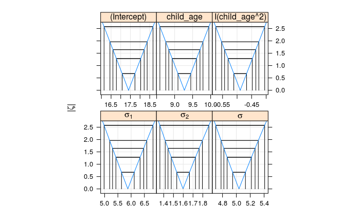

```r
xyplot(likelihood_profile, aspect = 1.3, absVal = TRUE)
```

The profile pairs plot is another informative plot. It shows two-dimensional 50%, 80%, 90%, 95% and 99% marginal confidence regions based on the likelihood ratio. These correspond to pairwise joint confidence regions. In the plot, profile traces indicate the conditional estimates of each parameter.

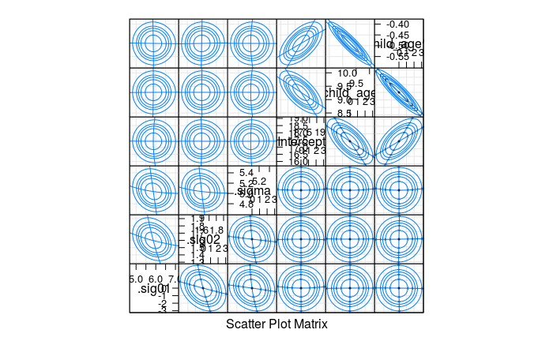

```r
splom(likelihood_profile)
```

We can also display an approximation of the probability density function of the sampling distribution for each parameter

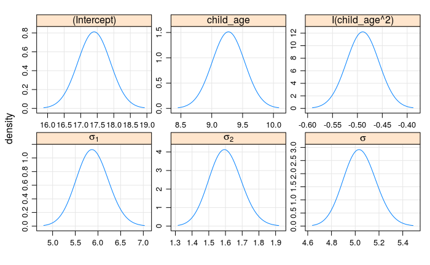

```r
densityplot(likelihood_profile)
```